# School participation across the year

Merly Klaas

2023-09-27

I did the initial cleaning in excel: Updating school name typo with school_id as the reference. There are many occurrences of school name inconsistencies with the same school id across the year. Now, each school_id corresponds to one identical school name. I then imported the cleaned dataset here.

```r
school <- import(here("data", "long_school.csv"))
```

Pivot wider data to count for total school participation

```r
school_wide <- school %>%
  group_by(school_id,school_name, year) %>%
  count(school_name) %>%
  pivot_wider(names_from = year, values_from = n) %>%
  mutate(total = rowSums(across(c("2019","2021", "2022", "2023")), na.rm=TRUE)) %>%
  select(school_id, school_name, "2019","2021", "2022", "2023", total)
school_wide
```

```
## # A tibble: 492 × 7
## # Groups:   school_id, school_name [492]
##    school_id school_name                      `2019` `2021` `2022` `2023` total
##        <int> <chr>                             <int>  <int>  <int>  <int> <dbl>
##  1         1 A2 Virtual + Academy                  1      1     NA     NA     2
##  2         3 The Academy of Advanced Learning      1      1     NA      1     3
##  3         4 Albemarle Road Elementary School      1     NA     NA     NA     1
##  4         6 Amana Academy                         1     NA     NA     NA     1
##  5         7 American Academy of Innovation        1     NA      1     NA     2
##  6         8 Anastasis Academy                     1      1      1      1     4
##  7         9 Armada High School                    1      1     NA     NA     2
##  8        10 Asa Messer Elementary School         NA      1     NA      1     2
##  9        11 Aspen Academy                         1      1      1     NA     3
## 10        15 Avalon School                         1      1     NA      1     3
## # ℹ 482 more rows
```

## Overall Number of school participated each year

*In 2023 we have the largest number of school participated (n=251), while 2022 is the least number of school participation (n=161).*

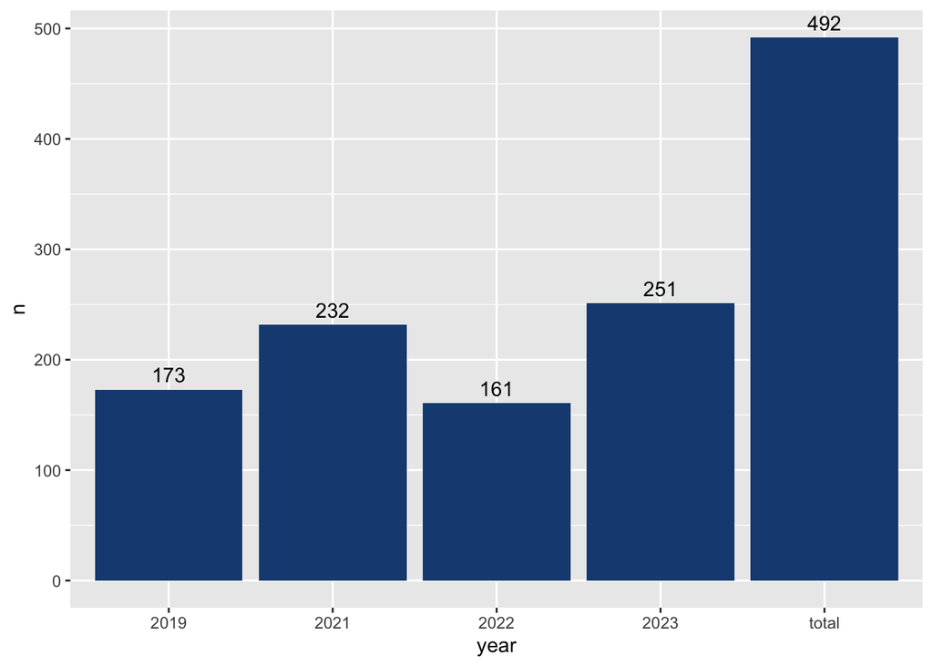

```r
school_wide %>%
pivot_longer(cols=c("2019","2021", "2022", "2023", total),
               names_to = "year",
               values_to = "count") %>%
    drop_na() %>%
  group_by(year) %>%
  count() %>%
  ggplot()+
  geom_col(aes(year, n), fill= "#1A4C81") +
   geom_text(aes(year, n,label = n), vjust = -0.5)
```

## Schools’ repeated participation trends across the year

```r
table(school_wide$total)
```

```
##
##   1   2   3   4
## 282 124  57  29
```

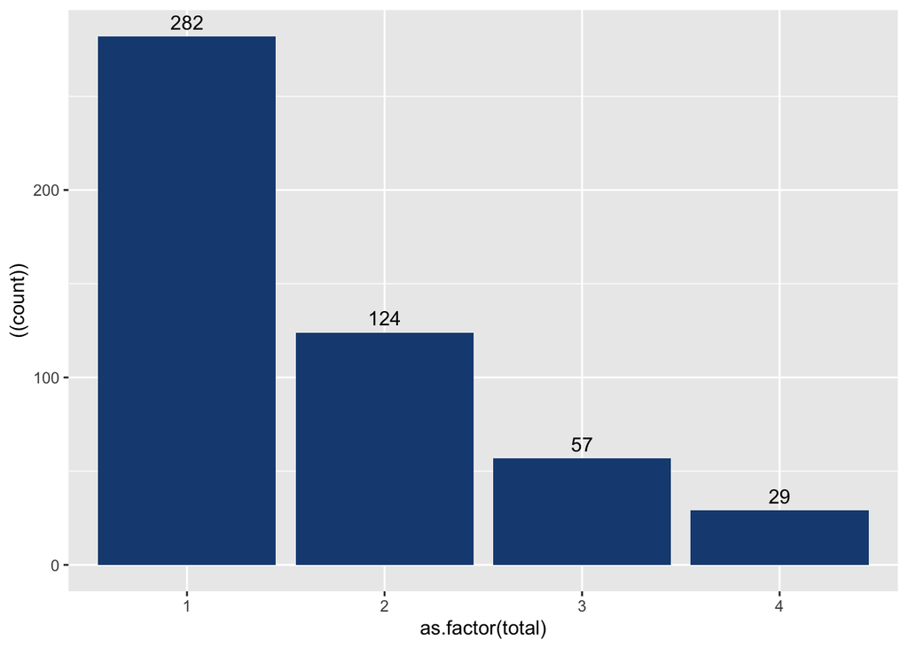

```r
school_wide %>%
 ggplot(aes(x=as.factor(total))) +
  geom_bar(fill="#1A4C81") +
  geom_text(aes(y = ((..count..)), label = (..count..)), stat = "count", vjust = -0.5)
```

## Each year and the accumulated school participation

Here we can see the trend of each school participation from 2019 - 2023 (gray = not participated, yellow = participated), and the far right is the total count of year participated. Color map confirmed the least participation happened in 2022.

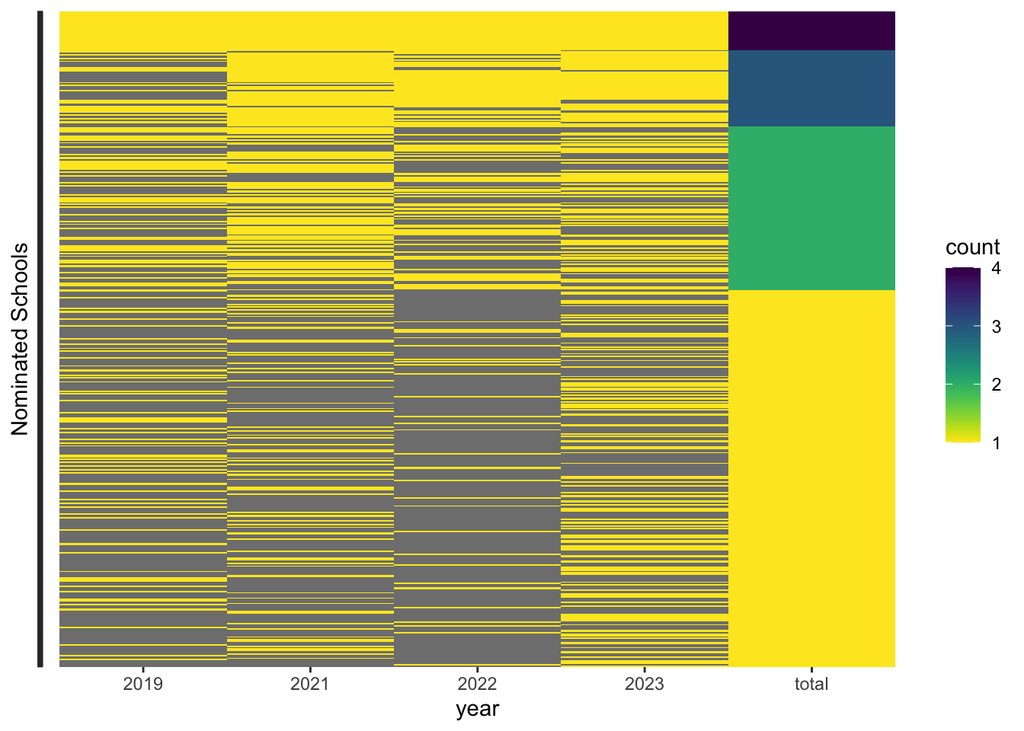

```r
school_wide %>%
  mutate(n = total) %>%
    pivot_longer(cols = c("2019","2021", "2022", "2023", total),
               names_to = "year",
               values_to = "count") %>%
   ggplot() +
  geom_tile(aes(year, y=fct_reorder(school_name, n), fill=count))+
   scale_fill_viridis(discrete=FALSE, direction=-1)+
  labs(y= "Nominated Schools")+
  theme(axis.text.y = element_blank())
```